# Food Waste from California Agriculture

Warren Watts

October 4, 2018

## California Agricultural Production and Wasted Food

California is a major agricultural state, although most people don’t think of agriculture when they think about California. Likewise wasted food is a major environmental problem that most people don’t think about when they think about the environment. This blog is an attempt to dive into the available data and take a look at how much of California’s edible agricultural output is wasted.

Food waste occurs at several levels. Food that has spoiled is thrown away in homes and grocery stores. Leftovers from restaurants and home cooking often go uneaten. Standards for produce also cause food waste as food is discarded that doesn’t look beautiful enough to be bought at the grocery store. The USDA produces data for agricultural production and provides estimates of home and retail food waste for different commodities. The estimates for produce that is discarded to meet standards are less official. Both will be examined in attempt to see how much of California’s agricultural production is wasted that could be eaten.

### California Agricultural Production Wasted at Home and Retail Levels

Home food waste has become even more obvious as more and more of us are asked to seperate our food waste from the rest of our garbage and we can see how much edible food or food that was once edible that we throw away. Food that is consumed in restaurants has a different path, but based on plate waste at restaraunts, it is a fair assumption that similar or greater amounts of food is wasted.

California is a major agricultural producer and leads the nation in productions of many types of food. The California Department of Food and Agriculture produces yearly statistical reports on California food production, which can be found [**at the CDFA’s website**](https://www.cdfa.ca.gov/Statistics/).

The U.S. Department of Agriculture has produced estimates of percentage of wasted food for different commodities at the home and retail level as part of *ERS Food Availability (Per Capita) Data System (FADS)*. [**Link to FADS Webpage**](https://www.ers.usda.gov/data-products/food-availability-per-capita-data-system/).

The following charts were generated by compiling the last 5 years of California food production data and applying the food loss estimate from the FADS system, in particular the yearly Loss Adjusted Food Availability (LAFA) tables.

First an overall look at all crops produced over the last 5 years for which data is available, 2012-2016.

The names of some of the commodities have suffixes to indicate whether the commodity is destined for fresh market (_FM), to be processed in canning or frozen (_Proc), be used dried (_Dried) like prunes, which or dried plums or dry (_Dry) which separates dried beans from fresh market snap beans.

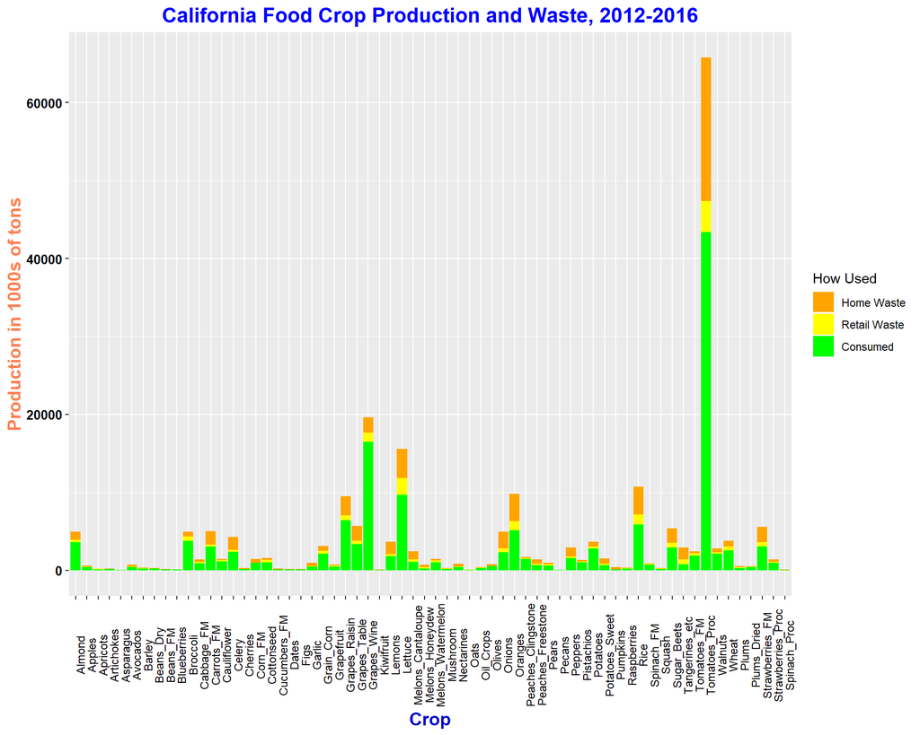

California produces huge amount of processed tomatoes a year, around 12M tons of the US’s 14M ton output. California produced more than 60M tons of tomatoes for processing in the 5 year period with over 20M tons going to waste at the home and retail level.

The second largest crop is grapes for wine, Waste estimates for grape juice were used for wine, as wine figures weren’t available. Likely more wine was wasted, although wine isn’t normally thought of as food.  
Leaving off the two largest crops allows us to get better detail for the rest of the crops in the next chart.

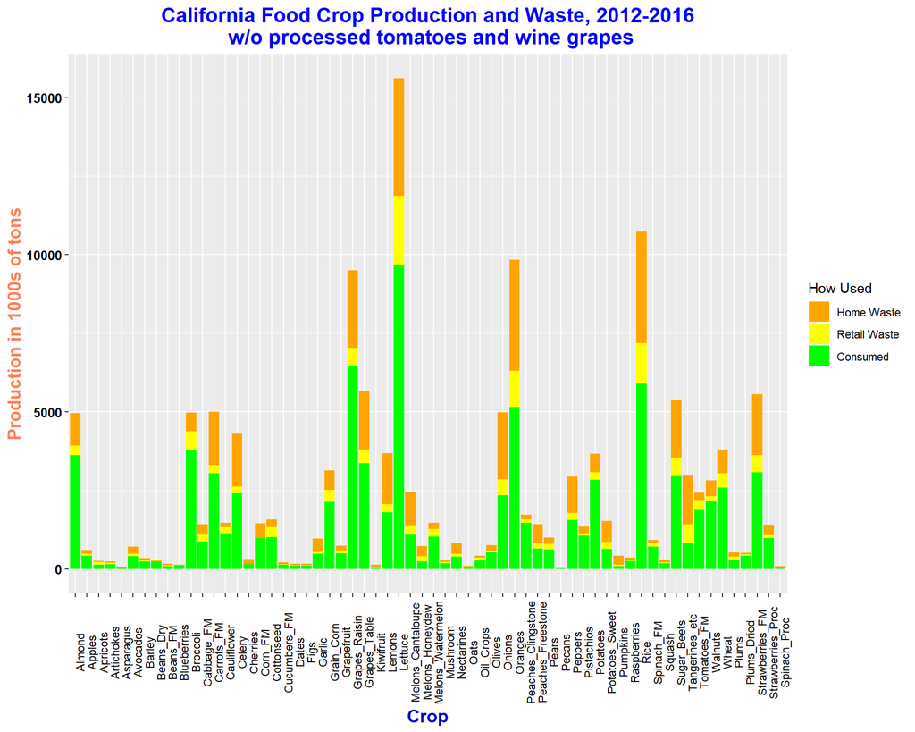

Lettuce now becomes the number one crop, with over 15M tons produced and 5M tons wasted. California also produces large quantities of oranges, rice and grapes for raisins that show similar waste patterns.  
Breaking the chart down into different categories of crops to get some better details:

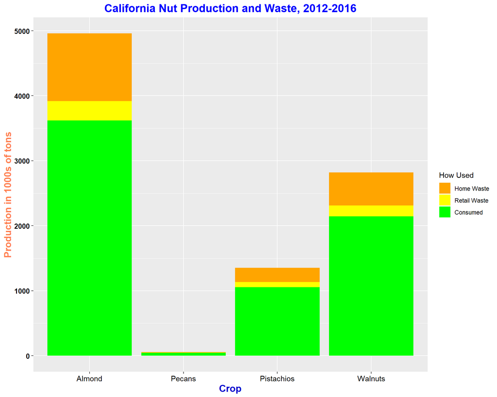

Nuts in general have lower waste, likely due to cost and the less perishable nature of nuts. California produced almost 5M tons of almonds over the 5 years with 1.2M tons wasted.

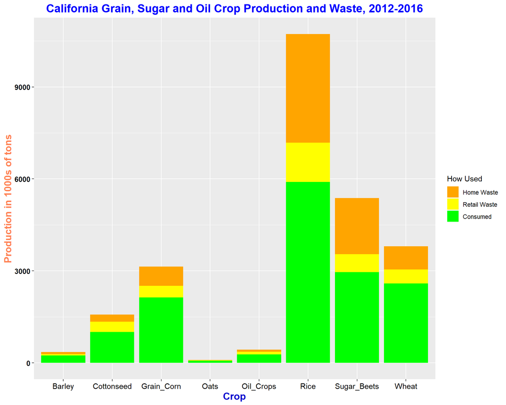

Rice is California’s major grain crop with almost 11M tons produced and 5M tons wasted. The rice waste figures are one of the few that seem a bit overstated, while wheat seems to be understated, based on the amount of rice and bread thrown away in my household anyway.

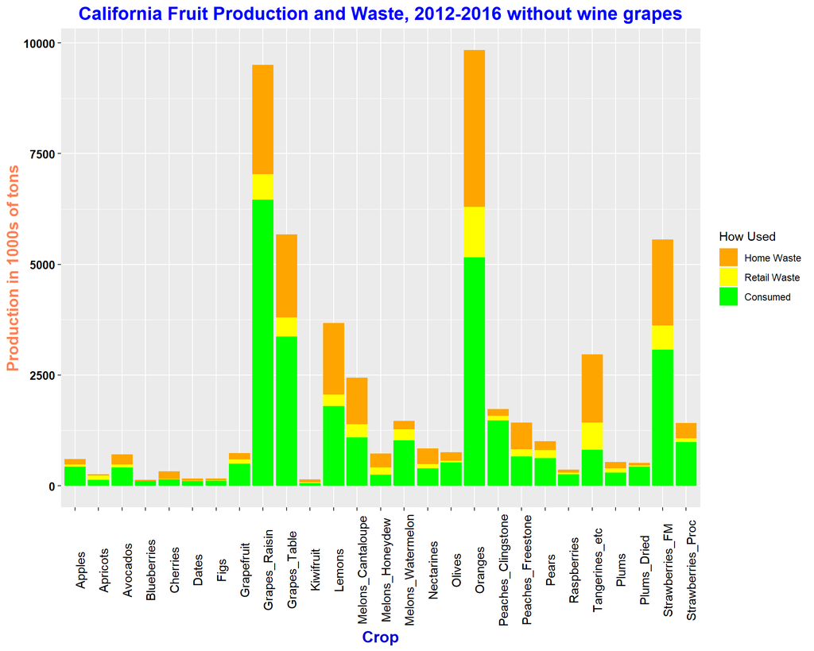

Looking at fruit production, oranges and raisins are major crops with 5 year production/waste numbers of 9.5M/4.5M and 9M/3M tons. Waste estimates for fresh market oranges were used as most of California’s oranges are used as produce, while Florida, which produces similar numbers of oranges, sends most of its production to juice. Other major fruit crops produced in California are table grapes and fresh market strawberries. Peaches are divided into clingstone, which are used for canning and freestone which are used as produce, which is the reason for their differing waste percentages.

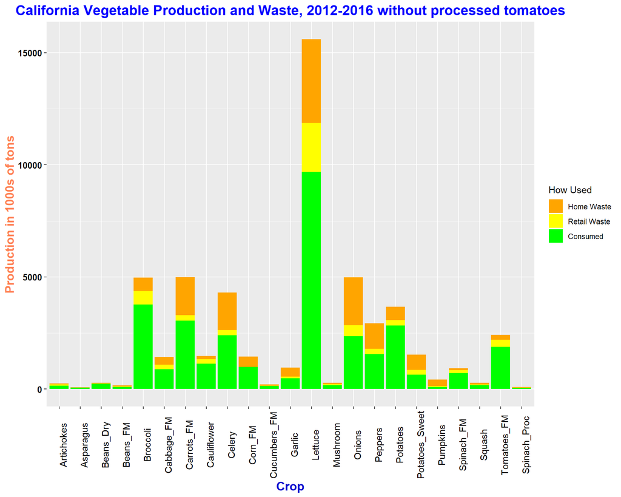

Vegetable production and waste is led by lettuce. Waste figures for broccoli and cauliflower are likely underestimated due to the USDA’s large estimates of unedible portions. The stems of broccoli and cauliflower are often discarded although they are generally edible if well cooked. The waste percentages for fresh market tomatoes also seem low from personal experience. Processed spinach numbers were only available for one year and real figures could be higher as California is the leading producer of spinach in the US.  
Finally an overall look at California’s crop production and waste based on categories of crop.

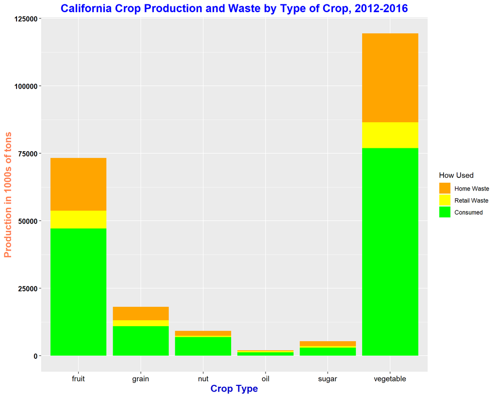

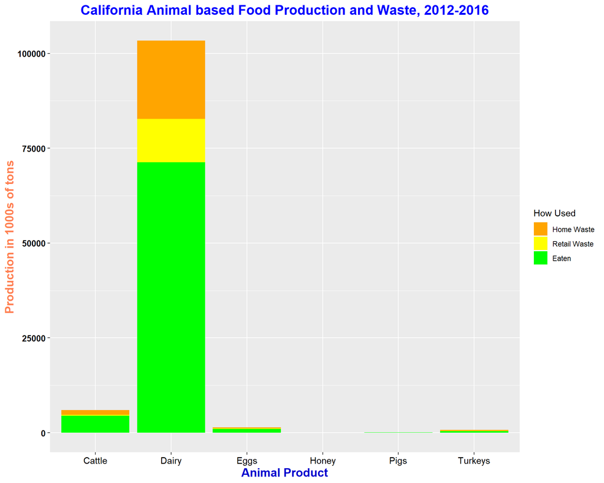

Dairy products, milk and cream, are the largest volume animal food produced in California by a large margin, with over 100M tons produced and over 30M tons wasted. California is the leading dairy producing state in the U.S.

Dairy production is a bit misleading because much of it is processed into other products like cheese, where much of it is evaporated. Dairy production is fairly efficient, however, with most of the nutritional value retained when milk is turned into other products. The one exception is the new fad of Greek yogurt which discards 2-3 pounds of acid whey for every pound of Greek yogurt produced. Fluffiness has it’s price.

The waste percentages on dairy are very conservative, milk home use was not revised in the 2009 study, and retains a 20% value from earlier estimates where everything was 20%. Other products like cheese were revised, but without a breakdown of dairy production use, the 20% figure was used. Milk, however, is a perishable product and the home waste figure overall for dairy is likely closer to the 30% revised values for most cheeses.  
Looking at non-dairy animal food products to get more detail:

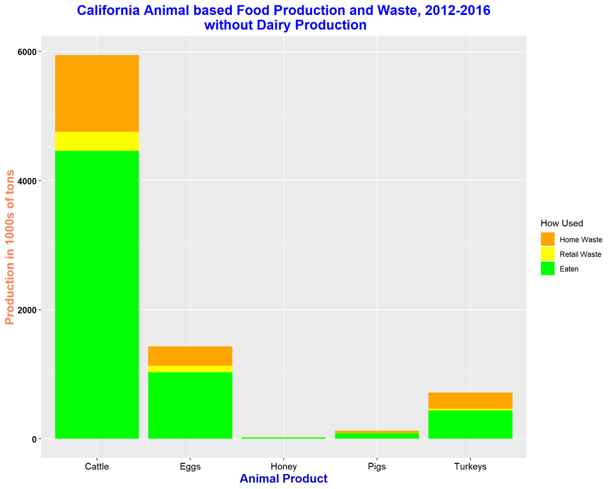

Without dairy, we can see that cattle production is the second largest animal product, with almost 6M tons produced and 1.5M tons wasted. Cattle includes cows and calves and calves raised for veal. Veal is very wasteful at retail level as it is a product that stores feel that they need to stock, but is not frequently bought, leading to much of it being thrown away. Fortunately veal production is a very small percentage of overall cattle production.

Another animal product with a lot of waste is turkey, likely due to the waste around Thanksgiving when everyone buys a turkey, but not all of the meat gets eaten. Pumpkins have a similar waste problem that is likely due to Halloween.

Numbers are not available for California chicken production because most chicken is produced by a single operation. Chicken meat production is likely much less than 1.8M tons a year, as that is the total for California and 10 other states. The USDA waste percentages estimates for chicken are 4% at the retail level and 15% at the home level.  
Comparing plant based crops and animal food products production and waste:

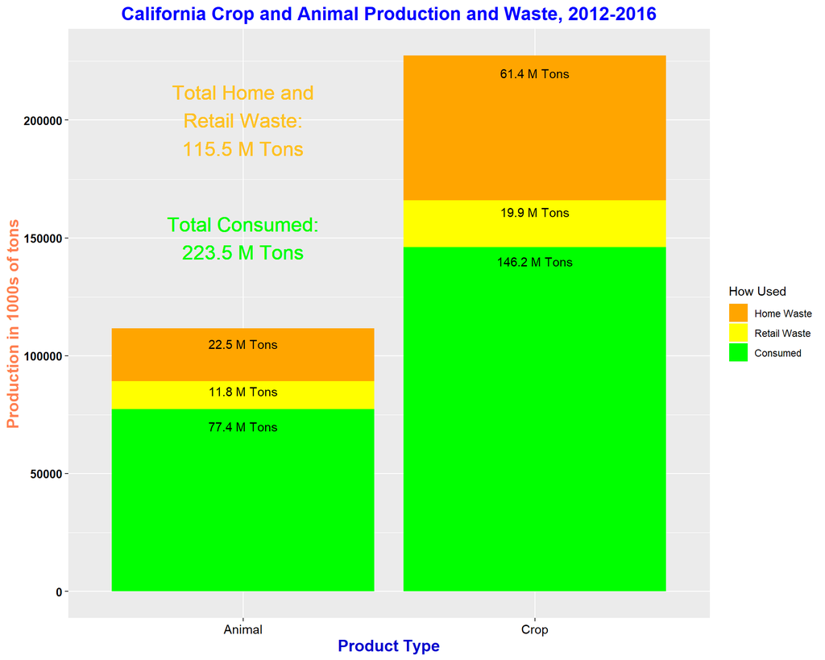

One third of the food produced in California is wasted at the home and retail level. Although a lower percentage of animal based food is wasted, animal based food production is much more expensive in resources and has a greater environmental impact.

Comparing Animal products to crops is a bit confusing as the USDA production figures include only the edible portions for meat and both the inedible and edible portions for crops. Depending on the crop inedible loss can be anywhere from 0% for grains, from 6% for strawberries to 50% for grapefruit in fruits and from 3% for mushrooms to 64% for fresh corn in vegetables. So the addage of the difficulty of comparing apples to oranges applies here. In addition over 50% of an animal is inedible for meat products, and dairy is used to make other products where much of the weight is evaporated or removed. The waste percentages are accurate, but the overall tonnage may be misleading.

### Comparing costs of animal food products to crop based foods.

The CDFA *California Agricultural Statistics Review* does provide some data that can allow comparison of the cost of producing animal based food versus the cost of producing plant based food. Yearly totals for the value of animal based food and plant based food are provided and farm origin and manufactured inputs are generally clear as to their destination in either crop or livestock production. Costs for labor, capital equipment and marketing are intermingled, but are likely similar for both animal and plant based food.

Total costs for seed, fertizer, pesticides and fuel were assigned to crops, costs for purchased livestock, feed and electricity were assigned to animals.

The following charts show year by year input costs for these resources and produced food values for livestock and crops:

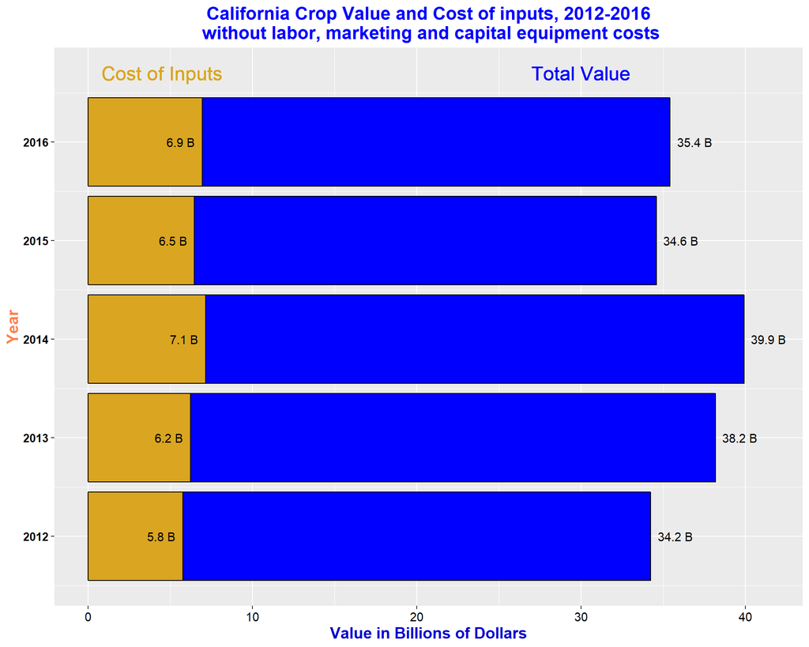

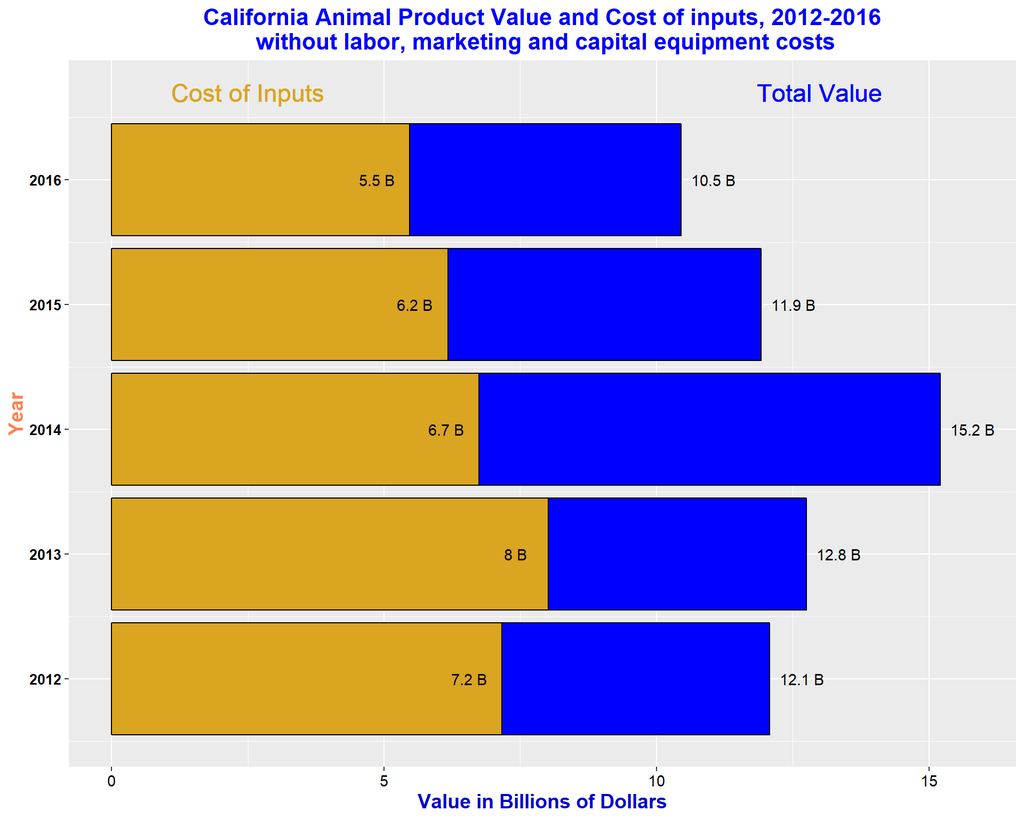

For crops the value of production to input cost ratio varies from 16-20%. For livestock the value of ranges from 44 to 63%. The resources required to produce the same value of animal based food is 2 to 3 times the resources required to produce plant based food in California.

### Preproduction Waste in Produce Due to Ugliness, Blemishes or Size

Produce is often rejected by retail buyers due to weird shapes, blemishes or the desire to have a standard size.

Estimates of how much produce is wasted range from 10-15% deemed not worth harvesting and 20-30% rejected by retailers and either thrown away or fed to animals. Unfortunately there is no government or standard body to produce estimates in this area so ancedotal estimates from farmers and companies trying to create a market for this produce are relied on.

Conservative figures of 10% unharvested and 20% rejected by retailers were used for the following charts. The charts are based on the assumption that rejected produce is not accounted for in USDA production numbers as full value is not realized for rejected fruits. For unharvested produce this assumption is certainly true, but there is no indication whether the USDA includes unused produce in its production numbers or not.

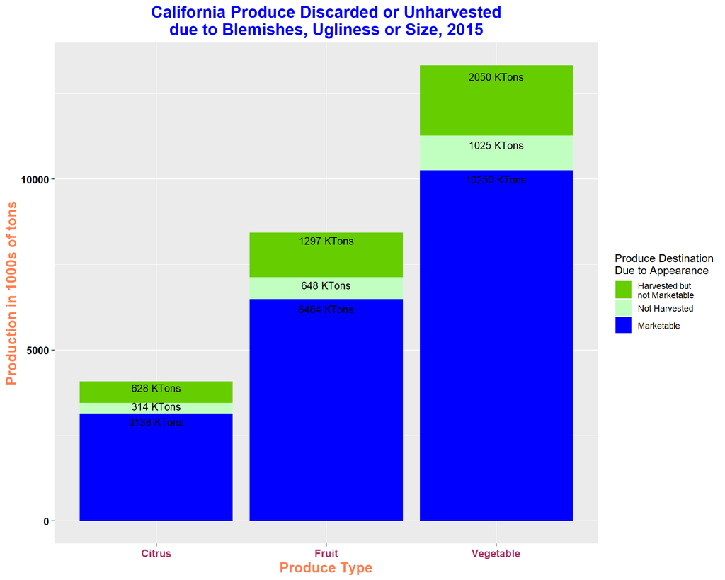

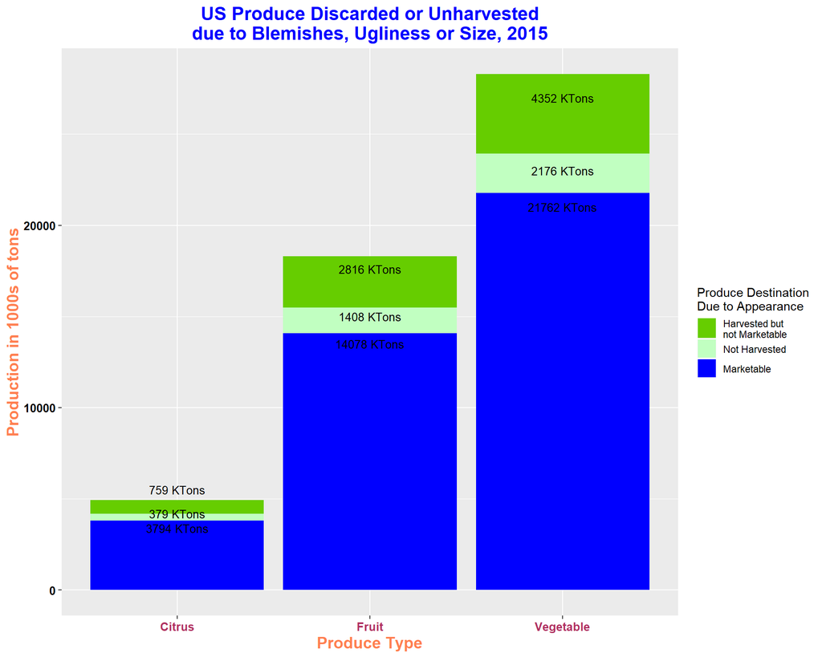

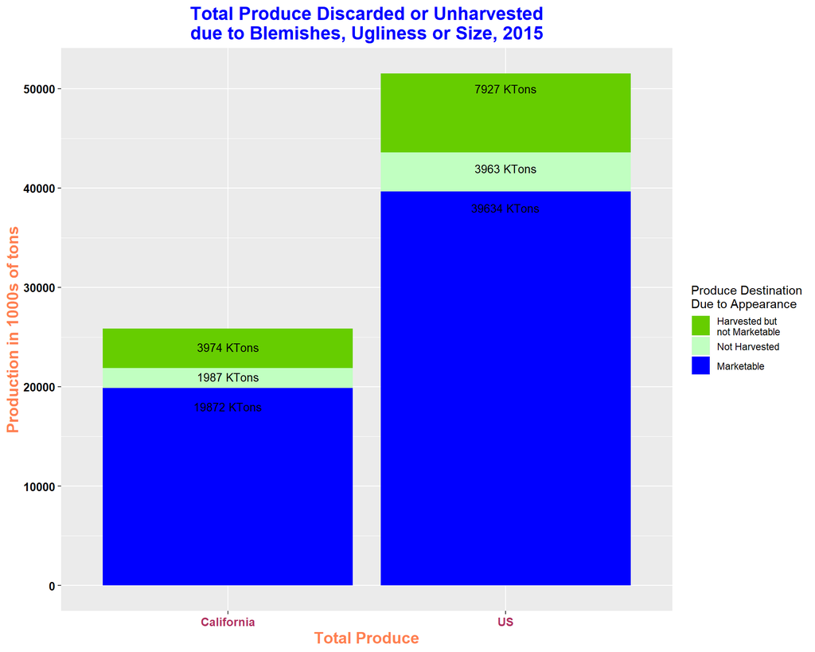

Numbers from 2015 were used because more recent years don’t seperate fresh market vegetables from processed vegetables.

Only the numbers for fresh market vegetables were used because tomatoes are the majority of processed vegetables and are used for things that don’t require perfect produce like tomato based sauces.

Only fresh market citrus was used because processed citrus is mostly used for juice.

For other fruits, processed and fresh market were combined as canned and dried fruits are often held to appearance standards and separate numbers were not available.

USDA annual crop reports were used for the US production numbers and the *California Agricultural Statistics Review* was used for California production numbers.

## Conclusion

Over the last 5 years of available data, California produced 68M tons of food annually. At the retail and home levels, 23M tons of this produce or more was likely wasted annually. In addition 6M Tons of produce or more was likely wasted annually because it didn’t meet retail standards of beauty. From these figures 39% of the food that California produces is wasted annually.